# McLaren_E_HW_Regression

## Regression HW

**Signature and K-State Honor Code**

E. McLaren. "On my honor, as a student, I have neither given nor received unauthorized aid on this academic work."

### Import packages

```python
import pandas as pd
import numpy as np
from scipy import stats
import seaborn as sns
import plotly.graph_objects as go
import plotly.express as px
import matplotlib.pyplot as plt
%matplotlib inline

#regression packages
import sklearn.linear_model as lm
from sklearn.metrics import mean_squared_error
from sklearn.metrics import explained_variance_score

#lasso regression
from sklearn import linear_model

#f_regression (feature selection)
from sklearn.feature_selection import f_regression
from sklearn.feature_selection import SelectKBest

# recursive feature selection (feature selection)
from sklearn.feature_selection import RFE

import statsmodels.api as sm
from statsmodels.formula.api import ols

# import the scatter_matrix functionality
from pandas.plotting import scatter_matrix

import pingouin as pg
```

## 1. Review the problem statement and the description about the columns (or variables) in the dataset, and develop at least two hypotheses1, which you can test using regression on the provided dataset. Provide the rationale for the hypotheses.

The dataset provided includes housing values in suburbs of Boston and the factors influencing the housing values. In order to better predict housing values, I will be using multiple line regression to test the importance of which variable will help in best determining this.

**Hypothesis 1:** I want to see if pupil to teacher ratio has a strong enough influence on determining housing values. The hypothesis I will test would be if the pupil to teacher ratio is lower, this makes the Median value of owner-occupied homes increase and be higher than if the ptratio is higher. My reasoning for this is that it is a general understanding that students who get more one-on-one time with their teacher perform better. This often influences the school's ratings and performance, and would in turn raise the cost to live in the school district.

**Hypothesis 2:** I want to see if nitric oxides concentration has a strong enough influence on determining housing values. The hypothesis I will test would be if the nitric oxides concentration is lower, this makes the Median value of owner-occupied homes decrease. My reasoning with this is that homes and residences in the center of large cities would likely experience more pollution, but due to their proximity to the city and reduced transport times, this would make these residences more expensive.

## 2. Demonstrate your data inspection skills (e.g., finding inconsistent/inaccurate data, duplicates). Make sure you need to handle those data quality issues before proceeding.

### Import data set

```python
# load b_housing.csv
df = pd.read_csv('data/b_housing.csv')
df.head()
```

|  | crim | zn | indus | chas | nox | rm | age | dis | rad | tax | ptratio | black | lstat | medv |
| --- | --- | --- | --- | --- | --- | --- | --- | --- | --- | --- | --- | --- | --- | --- |
| 0 | 0.00632 | 18.0 | 2.31 | 0 | 0.538 | 6.575 | 65.2 | 4.0900 | 1 | 296 | 15.3 | 396.90 | 4.98 | 24.0 |
| 1 | 0.02731 | 0.0 | 7.07 | 0 | 0.469 | 6.421 | 78.9 | 4.9671 | 2 | 242 | 17.8 | 396.90 | 9.14 | 21.6 |
| 2 | 0.02729 | 0.0 | 7.07 | 0 | 0.469 | 7.185 | 61.1 | 4.9671 | 2 | 242 | 17.8 | 392.83 | 4.03 | 34.7 |
| 3 | 0.03237 | 0.0 | 2.18 | 0 | 0.458 | 6.998 | 45.8 | 6.0622 | 3 | 222 | 18.7 | 394.63 | 2.94 | 33.4 |
| 4 | 0.06905 | 0.0 | 2.18 | 0 | 0.458 | 7.147 | 54.2 | 6.0622 | 3 | 222 | 18.7 | 396.90 | 5.33 | 36.2 |

```python
#get data types
df.info()
```

```
<class 'pandas.core.frame.DataFrame'>
RangeIndex: 508 entries, 0 to 507
Data columns (total 14 columns):
crim       508 non-null float64
zn         508 non-null float64
indus      508 non-null float64
chas       508 non-null int64
nox        508 non-null float64
rm         508 non-null float64
age        508 non-null float64
dis        508 non-null float64
rad        508 non-null int64
tax        508 non-null int64
ptratio    508 non-null float64
black      508 non-null float64
lstat      508 non-null float64
medv       508 non-null float64
dtypes: float64(11), int64(3)
memory usage: 55.6 KB
```

Since all of the data variables are integers or float, I will not need to worry about changing any categorical variables or objects to integers for correlation analysis later.

Now, I'll check the statistics of the data set to identify any inconsistencies or errors in the data set.

```python
# check data set statistics
df.describe()
```

|  | crim | zn | indus | chas | nox | rm | age | dis | rad | tax | ptratio | black | lstat | medv |
| --- | --- | --- | --- | --- | --- | --- | --- | --- | --- | --- | --- | --- | --- | --- |
| count | 508.000000 | 508.000000 | 508.000000 | 508.000000 | 508.000000 | 508.000000 | 508.000000 | 508.000000 | 508.000000 | 508.000000 | 508.000000 | 508.000000 | 508.000000 | 508.000000 |
| mean | 3.599645 | 11.368110 | 11.123917 | 0.068898 | 0.554574 | 6.283561 | 88.055315 | 3.801993 | 9.531496 | 407.854331 | 18.442717 | 356.827283 | 12.652185 | 22.534252 |
| std | 8.587406 | 23.276516 | 6.849870 | 0.253530 | 0.115665 | 0.701438 | 441.531284 | 2.104464 | 8.694746 | 168.314766 | 2.170287 | 91.147283 | 7.126976 | 9.178975 |
| min | 0.006320 | 0.000000 | 0.460000 | 0.000000 | 0.385000 | 3.561000 | 2.900000 | 1.129600 | 1.000000 | 187.000000 | 12.600000 | 0.320000 | 1.730000 | 5.000000 |
| 25% | 0.082155 | 0.000000 | 5.190000 | 0.000000 | 0.449000 | 5.886500 | 45.075000 | 2.100525 | 4.000000 | 279.000000 | 17.225000 | 375.472500 | 6.990000 | 17.075000 |
| 50% | 0.253715 | 0.000000 | 9.690000 | 0.000000 | 0.538000 | 6.205000 | 77.150000 | 3.215700 | 5.000000 | 330.000000 | 19.000000 | 391.475000 | 11.395000 | 21.200000 |
| 75% | 3.674807 | 12.500000 | 18.100000 | 0.000000 | 0.624000 | 6.620500 | 94.025000 | 5.214600 | 24.000000 | 666.000000 | 20.200000 | 396.215000 | 16.945000 | 25.000000 |
| max | 88.976200 | 100.000000 | 27.740000 | 1.000000 | 0.871000 | 8.780000 | 10000.000000 | 12.126500 | 24.000000 | 711.000000 | 22.000000 | 396.900000 | 37.970000 | 50.000000 |

The 'age' column has a maximum of 10,000 as a proportion of owner-occupied units built prior to 1940. At the most this should be 100% so I will change this entry and any others over 100.

Since the only row with an inconsistency is the one I already identified, I will change this value to 100 since it was likely an error when the data was entered. I'll then verify that the value was changed and that there are no other incorrect values.

```python
# changing age value of 10,000 with 100
#verify no more values  greater than 100
df = df.replace({'age': 10000}, {'age': 100})
df.head()
```

|  | crim | zn | indus | chas | nox | rm | age | dis | rad | tax | ptratio | black | lstat | medv |
| --- | --- | --- | --- | --- | --- | --- | --- | --- | --- | --- | --- | --- | --- | --- |
| 0 | 0.00632 | 18.0 | 2.31 | 0 | 0.538 | 6.575 | 65.2 | 4.0900 | 1 | 296 | 15.3 | 396.90 | 4.98 | 24.0 |
| 1 | 0.02731 | 0.0 | 7.07 | 0 | 0.469 | 6.421 | 78.9 | 4.9671 | 2 | 242 | 17.8 | 396.90 | 9.14 | 21.6 |
| 2 | 0.02729 | 0.0 | 7.07 | 0 | 0.469 | 7.185 | 61.1 | 4.9671 | 2 | 242 | 17.8 | 392.83 | 4.03 | 34.7 |
| 3 | 0.03237 | 0.0 | 2.18 | 0 | 0.458 | 6.998 | 45.8 | 6.0622 | 3 | 222 | 18.7 | 394.63 | 2.94 | 33.4 |
| 4 | 0.06905 | 0.0 | 2.18 | 0 | 0.458 | 7.147 | 54.2 | 6.0622 | 3 | 222 | 18.7 | 396.90 | 5.33 | 36.2 |

```python
df.describe()
```

|  | crim | zn | indus | chas | nox | rm | age | dis | rad | tax | ptratio | black | lstat | medv |
| --- | --- | --- | --- | --- | --- | --- | --- | --- | --- | --- | --- | --- | --- | --- |
| count | 508.000000 | 508.000000 | 508.000000 | 508.000000 | 508.000000 | 508.000000 | 508.000000 | 508.000000 | 508.000000 | 508.000000 | 508.000000 | 508.000000 | 508.000000 | 508.000000 |
| mean | 3.599645 | 11.368110 | 11.123917 | 0.068898 | 0.554574 | 6.283561 | 68.567126 | 3.801993 | 9.531496 | 407.854331 | 18.442717 | 356.827283 | 12.652185 | 22.534252 |
| std | 8.587406 | 23.276516 | 6.849870 | 0.253530 | 0.115665 | 0.701438 | 28.093559 | 2.104464 | 8.694746 | 168.314766 | 2.170287 | 91.147283 | 7.126976 | 9.178975 |
| min | 0.006320 | 0.000000 | 0.460000 | 0.000000 | 0.385000 | 3.561000 | 2.900000 | 1.129600 | 1.000000 | 187.000000 | 12.600000 | 0.320000 | 1.730000 | 5.000000 |
| 25% | 0.082155 | 0.000000 | 5.190000 | 0.000000 | 0.449000 | 5.886500 | 45.075000 | 2.100525 | 4.000000 | 279.000000 | 17.225000 | 375.472500 | 6.990000 | 17.075000 |
| 50% | 0.253715 | 0.000000 | 9.690000 | 0.000000 | 0.538000 | 6.205000 | 77.150000 | 3.215700 | 5.000000 | 330.000000 | 19.000000 | 391.475000 | 11.395000 | 21.200000 |
| 75% | 3.674807 | 12.500000 | 18.100000 | 0.000000 | 0.624000 | 6.620500 | 94.025000 | 5.214600 | 24.000000 | 666.000000 | 20.200000 | 396.215000 | 16.945000 | 25.000000 |
| max | 88.976200 | 100.000000 | 27.740000 | 1.000000 | 0.871000 | 8.780000 | 100.000000 | 12.126500 | 24.000000 | 711.000000 | 22.000000 | 396.900000 | 37.970000 | 50.000000 |

Since no other rows were listed, I can be certain there are no other false entries for the 'age' column.

Now I'll check for any missing values in the data set.

```python
#find amount of missing values
df.isnull().sum().sort_values(ascending=False)
```

```
medv       0
lstat      0
black      0
ptratio    0
tax        0
rad        0
dis        0
age        0
rm         0
nox        0
chas       0
indus      0
zn         0
crim       0
dtype: int64
```

There are no missing values in the data set that I need to resolve.

Now I'll check for duplicate records.

```python
# count duplicate records
df.duplicated().sum()
```

```
2
```

```python
# examine duplicated rows, code sourced from: https://www.ritchieng.com/pandas-removing-duplicate-rows/
df.loc[df.duplicated(keep=False), :]
```

|  | crim | zn | indus | chas | nox | rm | age | dis | rad | tax | ptratio | black | lstat | medv |
| --- | --- | --- | --- | --- | --- | --- | --- | --- | --- | --- | --- | --- | --- | --- |
| 6 | 0.08829 | 12.5 | 7.87 | 0 | 0.524 | 6.012 | 66.6 | 5.5605 | 5 | 311 | 15.2 | 395.6 | 12.43 | 22.9 |
| 506 | 0.08829 | 12.5 | 7.87 | 0 | 0.524 | 6.012 | 66.6 | 5.5605 | 5 | 311 | 15.2 | 395.6 | 12.43 | 22.9 |
| 507 | 0.08829 | 12.5 | 7.87 | 0 | 0.524 | 6.012 | 66.6 | 5.5605 | 5 | 311 | 15.2 | 395.6 | 12.43 | 22.9 |

I can see that there are two extra varsions of entries in the data set, rows 506 and 507 which are duplicates of row 6.

In the next step, I'll remove these two duplicates and keep the first instance, row 6.

```python
# drops the duplicate rows, code sourced from: https://www.ritchieng.com/pandas-removing-duplicate-rows/
# update dataset to not include the duplicate records, "inplace=True" code sourced from https://stackoverflow.com/questions/23667369/drop-all-duplicate-rows-in-python-pandas
df.drop_duplicates(keep='first', inplace=True)
```

```python
#check for missing values
df.shape
```

```
(506, 14)
```

I then verify that the number of rows has decreased by two, which it has. It has gone from 508 to 506, meaning the two duplicates have been removed.

## 3. Demonstrate your data visualization skills (e.g., charts, pivot tables). You should explore matplot, seaborn, and interactive plots. The focus should be on identifying X variables (independent variables) affecting Y value (dependent variable, MEDV in the dataset). What X variables appear to influence on the median housing price in Boston?

In this first visual, there is an apparent correlation between rooms in a home and their median value. There is still some variation in this, so I will test this later in a correlation analysis.

```python
##relationship between rooms in a home and their median value
data = df[['rm','zn','black','lstat','indus','tax','ptratio','nox','medv', 'age']]
data = data.sort_values('medv',ascending=False)
px.scatter(data, x="rm", y="medv", hover_data=['medv','rm'],  color="nox", size='rm', trendline="ols")
```

[interactive chart not shown]

In the visual below, there appears to be a very slight positive relationship between proportion of residential land zoned for lots over 25,000 sq.ft. and median home value. I predict I will not see this variable be a super helpful variable in determining home value.

```python
#relationship between proportion of residential land zoned for lots over 25,000 sq.ft. and median home value
data = df[['rm','zn','black','lstat','indus','tax','ptratio','nox','medv', 'age']]
data = data.sort_values('medv',ascending=False)
px.scatter(data, x="zn", y="medv", hover_data=['medv','zn'],  color="nox", size='zn', trendline="ols")
```

[interactive chart not shown]

The visual below shows the relationship between the proportion of black people and home value. Judging by this image, I also don't expect this variable to be a good predictor later on.

```python
#relationship between the proportion of black people and median home value
data = df[['rm','zn','black','lstat','indus','tax','ptratio','nox','medv', 'age']]
data = data.sort_values('medv',ascending=False)
px.scatter(data, x="black", y="medv", hover_data=['medv','black'],  color="nox",trendline="ols")
```

[interactive chart not shown]

Based on this visualization, I want to see more about the potential correlation between lower status of the population and median home value. It shows to have more of a curve to it's shape, so I don't expect the regression analysis to place this variable very high on the list.

```python
#relationship between lower status of the population and median home value
data = df[['rm','zn','black','lstat','indus','tax','ptratio','nox','medv','age']]
data = data.sort_values('medv',ascending=False)
px.scatter(data, x="lstat", y="medv", hover_data=['medv','lstat'],  color="nox", size='lstat', trendline="ols")
```

[interactive chart not shown]

In the visualization below, there is a slight negative relationship between proportion of non-retail business acres per town and median home value. I don't expect this variable to perform highly in the correlation analysis since the slope appears to be flatter.

```python
##relationship between proportion of non-retail business acres per town and median home value
data = df[['rm','zn','black','lstat','indus','tax','ptratio','nox','medv','age']]
data = data.sort_values('medv',ascending=False)
px.scatter(data, x="indus", y="medv", hover_data=['medv','indus'],  color="nox", trendline="ols")
```

[interactive chart not shown]

In the visualization below, there is a slight negative relationship between tax rates and median home value. Judging by this plot, I don't expect this variable to be a good predictor after more analysis.

```python
#relationship between tax rates and median home value
data = df[['rm','zn','black','lstat','indus','tax','ptratio','nox','medv','age']]
data = data.sort_values('medv',ascending=False)
px.scatter(data, x="tax", y="medv", hover_data=['medv','tax'],  color="nox", trendline="ols")
```

[interactive chart not shown]

In the below visual, it shows the negative relationship between student teacher ratio and median home value. It is hard to tell if the apparent correlation in this plot will be true when I do the correlation analysis.

```python
#relationship between student teacher ratio and median home value
data = df[['rm','zn','black','lstat','indus','tax','ptratio','nox','medv','age']]
data = data.sort_values('medv',ascending=False)
px.scatter(data, x="ptratio", y="medv", hover_data=['medv','ptratio'],  color="nox", trendline="ols")
```

[interactive chart not shown]

In the scatter plot below, there is a negative relationship between nitric oxide concentration and median home value. I am curoius to see if this yield similar results after correlation analysis.

```python
#relationship between nitric oxide concentration and median home value
data = df[['rm','zn','black','lstat','indus','tax','ptratio','nox','medv','age']]
data = data.sort_values('medv',ascending=False)
px.scatter(data, x="nox", y="medv", hover_data=['medv','nox'],  color="nox", trendline="ols")
```

[interactive chart not shown]

## 4. Demonstrate your exploratory data analysis (EDA) skills (e.g., correlation analysis, heatmap). What X variables appear to influence on the median housing price in Boston? What X variables are highly correlated to each other?

```python
# data set basic statistics
df.describe()
```

|  | crim | zn | indus | chas | nox | rm | age | dis | rad | tax | ptratio | black | lstat | medv |
| --- | --- | --- | --- | --- | --- | --- | --- | --- | --- | --- | --- | --- | --- | --- |
| count | 506.000000 | 506.000000 | 506.000000 | 506.000000 | 506.000000 | 506.000000 | 506.000000 | 506.000000 | 506.000000 | 506.000000 | 506.000000 | 506.000000 | 506.000000 | 506.000000 |
| mean | 3.613524 | 11.363636 | 11.136779 | 0.069170 | 0.554695 | 6.284634 | 68.574901 | 3.795043 | 9.549407 | 408.237154 | 18.455534 | 356.674032 | 12.653063 | 22.532806 |
| std | 8.601545 | 23.322453 | 6.860353 | 0.253994 | 0.115878 | 0.702617 | 28.148861 | 2.105710 | 8.707259 | 168.537116 | 2.164946 | 91.294864 | 7.141062 | 9.197104 |
| min | 0.006320 | 0.000000 | 0.460000 | 0.000000 | 0.385000 | 3.561000 | 2.900000 | 1.129600 | 1.000000 | 187.000000 | 12.600000 | 0.320000 | 1.730000 | 5.000000 |
| 25% | 0.082045 | 0.000000 | 5.190000 | 0.000000 | 0.449000 | 5.885500 | 45.025000 | 2.100175 | 4.000000 | 279.000000 | 17.400000 | 375.377500 | 6.950000 | 17.025000 |
| 50% | 0.256510 | 0.000000 | 9.690000 | 0.000000 | 0.538000 | 6.208500 | 77.500000 | 3.207450 | 5.000000 | 330.000000 | 19.050000 | 391.440000 | 11.360000 | 21.200000 |
| 75% | 3.677082 | 12.500000 | 18.100000 | 0.000000 | 0.624000 | 6.623500 | 94.075000 | 5.188425 | 24.000000 | 666.000000 | 20.200000 | 396.225000 | 16.955000 | 25.000000 |
| max | 88.976200 | 100.000000 | 27.740000 | 1.000000 | 0.871000 | 8.780000 | 100.000000 | 12.126500 | 24.000000 | 711.000000 | 22.000000 | 396.900000 | 37.970000 | 50.000000 |

```python
#correlation analysis
df.corr()
```

|  | crim | zn | indus | chas | nox | rm | age | dis | rad | tax | ptratio | black | lstat | medv |
| --- | --- | --- | --- | --- | --- | --- | --- | --- | --- | --- | --- | --- | --- | --- |
| crim | 1.000000 | -0.200469 | 0.406583 | -0.055892 | 0.420972 | -0.219247 | 0.352734 | -0.379670 | 0.625505 | 0.582764 | 0.289946 | -0.385064 | 0.455621 | -0.388305 |
| zn | -0.200469 | 1.000000 | -0.533828 | -0.042697 | -0.516604 | 0.311991 | -0.569537 | 0.664408 | -0.311948 | -0.314563 | -0.391679 | 0.175520 | -0.412995 | 0.360445 |
| indus | 0.406583 | -0.533828 | 1.000000 | 0.062938 | 0.763651 | -0.391676 | 0.644779 | -0.708027 | 0.595129 | 0.720760 | 0.383248 | -0.356977 | 0.603800 | -0.483725 |
| chas | -0.055892 | -0.042697 | 0.062938 | 1.000000 | 0.091203 | 0.091251 | 0.086518 | -0.099176 | -0.007368 | -0.035587 | -0.121515 | 0.048788 | -0.053929 | 0.175260 |
| nox | 0.420972 | -0.516604 | 0.763651 | 0.091203 | 1.000000 | -0.302188 | 0.731470 | -0.769230 | 0.611441 | 0.668023 | 0.188933 | -0.380051 | 0.590879 | -0.427321 |
| rm | -0.219247 | 0.311991 | -0.391676 | 0.091251 | -0.302188 | 1.000000 | -0.240265 | 0.205246 | -0.209847 | -0.292048 | -0.355501 | 0.128069 | -0.613808 | 0.695360 |
| age | 0.352734 | -0.569537 | 0.644779 | 0.086518 | 0.731470 | -0.240265 | 1.000000 | -0.747881 | 0.456022 | 0.506456 | 0.261515 | -0.273534 | 0.602339 | -0.376955 |
| dis | -0.379670 | 0.664408 | -0.708027 | -0.099176 | -0.769230 | 0.205246 | -0.747881 | 1.000000 | -0.494588 | -0.534432 | -0.232471 | 0.291512 | -0.496996 | 0.249929 |
| rad | 0.625505 | -0.311948 | 0.595129 | -0.007368 | 0.611441 | -0.209847 | 0.456022 | -0.494588 | 1.000000 | 0.910228 | 0.464741 | -0.444413 | 0.488676 | -0.381626 |
| tax | 0.582764 | -0.314563 | 0.720760 | -0.035587 | 0.668023 | -0.292048 | 0.506456 | -0.534432 | 0.910228 | 1.000000 | 0.460853 | -0.441808 | 0.543993 | -0.468536 |
| ptratio | 0.289946 | -0.391679 | 0.383248 | -0.121515 | 0.188933 | -0.355501 | 0.261515 | -0.232471 | 0.464741 | 0.460853 | 1.000000 | -0.177383 | 0.374044 | -0.507787 |
| black | -0.385064 | 0.175520 | -0.356977 | 0.048788 | -0.380051 | 0.128069 | -0.273534 | 0.291512 | -0.444413 | -0.441808 | -0.177383 | 1.000000 | -0.366087 | 0.333461 |
| lstat | 0.455621 | -0.412995 | 0.603800 | -0.053929 | 0.590879 | -0.613808 | 0.602339 | -0.496996 | 0.488676 | 0.543993 | 0.374044 | -0.366087 | 1.000000 | -0.737663 |
| medv | -0.388305 | 0.360445 | -0.483725 | 0.175260 | -0.427321 | 0.695360 | -0.376955 | 0.249929 | -0.381626 | -0.468536 | -0.507787 | 0.333461 | -0.737663 | 1.000000 |

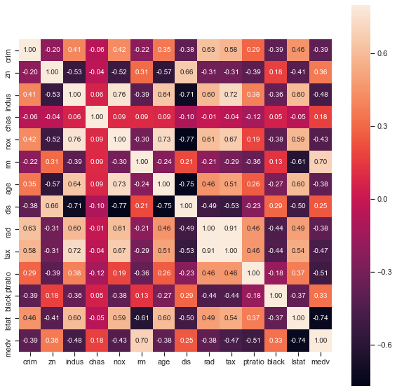

```python
# show correlation plot
plt.figure(figsize=(10,10))
sns.heatmap(df.corr(), vmax=.8, square=True, annot=True, fmt=".2f");
```

From the above correlation heatmap, I can see that there are some strong correlations between the median value of owner-occupied homes and variables from the data set.

**Positive** relationship with median value of owner-occupied homes:

- 'rm' - average number of rooms per dwelling
- 'zn' - proportion of residential land zoned for lots over 25,000 sq.ft.
- 'black' - proportion of black people by town

**Negative** relationship with median value of owner-occupied homes:

- 'lstat' - % lower status of the population
- 'indus' - proportion of non-retail business acres per town.
- 'tax' - full-value property-tax rate per $10,000
- 'ptratio' - pupil-teacher ratio by town
- 'nox' - nitric oxides concentration (parts per 10 million)

**To summarize what the correlations between these mean:**

- the higher the proportion of black people, the higher the median home value
- the higher the average number of rooms per home, the higher the median home value
- the higher the proportion of residential land zoned for large lots, the higher the median home value
- the higher the % lower status of the population, the lower the median home value
- the higher the proportion of non-retail business acres per town, the lower the median home value
- the higher the tax rate, the lower the median home value
- the higher the pupil-teacher ratio by town, the lower the median home value
- the higher the nitric oxides concentration, the lower the median home value

I can also see that there are some strong correlations between the X variables in the data set.

**Positive** relationships:

- 'rad' and 'tax' - index of accessibility to radial highways and full-value property-tax rate per 10,000 dollars
- 'indus' and 'nox' - proportion of non-retail business acres per town and nitric oxides concentration
- 'nox' and 'age' - nitric oxides concentration and proportion of owner-occupied units built prior to 1940
- 'indus' and 'tax' - proportion of non-retail business acres per town and full-value property-tax rate per 10,000 dollars

**Negative** relationships:

- 'zn' and 'indus' - proportion of residential land zoned for lots over 25,000 sq.ft. and proportion of non-retail business acres per town.
- 'zn' and 'nox' - proportion of residential land zoned for lots over 25,000 sq.ft. and nitric oxides concentration
- 'dis' and 'age' - weighted distances to five Boston employment centres and proportion of owner-occupied units built prior to 1940
- 'dis' and 'nox' - weighted distances to five Boston employment centres and nitric oxides concentration
- 'rm' and 'lstat' - average number of rooms per dwelling and % lower status of the population

**To summarize what the correlations between these mean:**

- the higher the index of accessibility to radial highways, the higher the full-value property-tax rate per 10,000 dollars
- the higher the proportion of non-retail business acres per town, the higher the nitric oxides concentration
- the higher the nitric oxides concentration, the higher the roportion of owner-occupied units built prior to 1940
- the higher the proportion of non-retail business acres per town, the higher the full-value property-tax rate per 10,000 dollars
- the higher the proportion of residential land zoned for lots over 25,000 sq.ft., the lower the proportion of non-retail business acres per town
- the higher the proportion of residential land zoned for lots over 25,000 sq.ft., the lower the nitric oxides concentration
- the higher the weighted distances to five Boston employment centres, the lower the proportion of owner-occupied units built prior to 1940
- the higher the weighted distances to five Boston employment centres, the lower the nitric oxides concentration
- the higher the average number of rooms per dwelling, the lower the % lower status of the population

## 5. Demonstrate your skills in building and evaluating regression models. Initially, you need to build a multiple regression model. It is important that you use both scikit-learn2 and statmodel. You need to report the regression results and provide your interpretations (e.g., coefficients, p-value, R-squared).

### Scikit-learn2 model

```python
#assigning columns to X and Y variables
y = df['medv']
X = df.drop(['medv'], axis =1)
```

```python
sk_model1 = lm.LinearRegression()
sk_model1.fit(X, y)
model1_y = sk_model1.predict(X)
```

```python
# The coefficients
print('Coefficients: ', sk_model1.coef_)
# y-intercept
print("y-intercept ", sk_model1.intercept_)
```

```
Coefficients:  [-1.08011358e-01  4.64204584e-02  2.05586264e-02  2.68673382e+00
 -1.77666112e+01  3.80986521e+00  6.92224640e-04 -1.47556685e+00
  3.06049479e-01 -1.23345939e-02 -9.52747232e-01  9.31168327e-03
 -5.24758378e-01]
y-intercept  36.459488385090005
```

```python
coef = ["%.3f" % i for i in sk_model1.coef_]
xcolumns = [ i for i in X.columns ]
list(zip(xcolumns, coef))
```

```
[('crim', '-0.108'),
 ('zn', '0.046'),
 ('indus', '0.021'),
 ('chas', '2.687'),
 ('nox', '-17.767'),
 ('rm', '3.810'),
 ('age', '0.001'),
 ('dis', '-1.476'),
 ('rad', '0.306'),
 ('tax', '-0.012'),
 ('ptratio', '-0.953'),
 ('black', '0.009'),
 ('lstat', '-0.525')]
```

```python
print("mean square error: ", mean_squared_error(y, model1_y))
print("variance or r-squared: ", explained_variance_score(y, model1_y))
```

```
mean square error:  21.894831181729206
variance or r-squared:  0.7406426641094094
```

```python
#statmodel
# without two columns: 2B, 3B (Python does not like the variables starting with number)
runs_reg_model = ols("medv~crim+zn+indus+chas+nox+rm+age+dis+rad+tax+ptratio+black+lstat",df)
runs_reg = runs_reg_model.fit()
print(runs_reg.summary())
```

```
                            OLS Regression Results
==============================================================================
Dep. Variable:                   medv   R-squared:                       0.741
Model:                            OLS   Adj. R-squared:                  0.734
Method:                 Least Squares   F-statistic:                     108.1
Date:                Wed, 23 Oct 2019   Prob (F-statistic):          6.72e-135
Time:                        23:33:41   Log-Likelihood:                -1498.8
No. Observations:                 506   AIC:                             3026.
Df Residuals:                     492   BIC:                             3085.
Df Model:                          13
Covariance Type:            nonrobust
==============================================================================
                 coef    std err          t      P>|t|      [0.025      0.975]
------------------------------------------------------------------------------
Intercept     36.4595      5.103      7.144      0.000      26.432      46.487
crim          -0.1080      0.033     -3.287      0.001      -0.173      -0.043
zn             0.0464      0.014      3.382      0.001       0.019       0.073
indus          0.0206      0.061      0.334      0.738      -0.100       0.141
chas           2.6867      0.862      3.118      0.002       0.994       4.380
nox          -17.7666      3.820     -4.651      0.000     -25.272     -10.262
rm             3.8099      0.418      9.116      0.000       2.989       4.631
age            0.0007      0.013      0.052      0.958      -0.025       0.027
dis           -1.4756      0.199     -7.398      0.000      -1.867      -1.084
rad            0.3060      0.066      4.613      0.000       0.176       0.436
tax           -0.0123      0.004     -3.280      0.001      -0.020      -0.005
ptratio       -0.9527      0.131     -7.283      0.000      -1.210      -0.696
black          0.0093      0.003      3.467      0.001       0.004       0.015
lstat         -0.5248      0.051    -10.347      0.000      -0.624      -0.425
==============================================================================
Omnibus:                      178.041   Durbin-Watson:                   1.078
Prob(Omnibus):                  0.000   Jarque-Bera (JB):              783.126
Skew:                           1.521   Prob(JB):                    8.84e-171
Kurtosis:                       8.281   Cond. No.                     1.51e+04
==============================================================================

Warnings:
[1] Standard Errors assume that the covariance matrix of the errors is correctly specified.
[2] The condition number is large, 1.51e+04. This might indicate that there are
strong multicollinearity or other numerical problems.
```

```python
# without 2 columns: indus, age (Python does not like the variables starting with number)
runs_reg_model2 = ols("medv~crim+zn+chas+nox+rm+dis+rad+tax+ptratio+black+lstat",df)
runs_reg2 = runs_reg_model2.fit()
print(runs_reg2.summary())
```

```
                            OLS Regression Results
==============================================================================
Dep. Variable:                   medv   R-squared:                       0.741
Model:                            OLS   Adj. R-squared:                  0.735
Method:                 Least Squares   F-statistic:                     128.2
Date:                Wed, 23 Oct 2019   Prob (F-statistic):          5.54e-137
Time:                        23:33:41   Log-Likelihood:                -1498.9
No. Observations:                 506   AIC:                             3022.
Df Residuals:                     494   BIC:                             3072.
Df Model:                          11
Covariance Type:            nonrobust
==============================================================================
                 coef    std err          t      P>|t|      [0.025      0.975]
------------------------------------------------------------------------------
Intercept     36.3411      5.067      7.171      0.000      26.385      46.298
crim          -0.1084      0.033     -3.307      0.001      -0.173      -0.044
zn             0.0458      0.014      3.390      0.001       0.019       0.072
chas           2.7187      0.854      3.183      0.002       1.040       4.397
nox          -17.3760      3.535     -4.915      0.000     -24.322     -10.430
rm             3.8016      0.406      9.356      0.000       3.003       4.600
dis           -1.4927      0.186     -8.037      0.000      -1.858      -1.128
rad            0.2996      0.063      4.726      0.000       0.175       0.424
tax           -0.0118      0.003     -3.493      0.001      -0.018      -0.005
ptratio       -0.9465      0.129     -7.334      0.000      -1.200      -0.693
black          0.0093      0.003      3.475      0.001       0.004       0.015
lstat         -0.5226      0.047    -11.019      0.000      -0.616      -0.429
==============================================================================
Omnibus:                      178.430   Durbin-Watson:                   1.078
Prob(Omnibus):                  0.000   Jarque-Bera (JB):              787.785
Skew:                           1.523   Prob(JB):                    8.60e-172
Kurtosis:                       8.300   Cond. No.                     1.47e+04
==============================================================================

Warnings:
[1] Standard Errors assume that the covariance matrix of the errors is correctly specified.
[2] The condition number is large, 1.47e+04. This might indicate that there are
strong multicollinearity or other numerical problems.
```

```python
# Develop the 3rd model

runs_reg_model3 = ols("medv~nox+rm+dis+ptratio+lstat",df)
runs_reg3 = runs_reg_model3.fit()
print(runs_reg3.summary())
```

```
                            OLS Regression Results
==============================================================================
Dep. Variable:                   medv   R-squared:                       0.708
Model:                            OLS   Adj. R-squared:                  0.705
Method:                 Least Squares   F-statistic:                     242.6
Date:                Wed, 23 Oct 2019   Prob (F-statistic):          3.67e-131
Time:                        23:33:41   Log-Likelihood:                -1528.7
No. Observations:                 506   AIC:                             3069.
Df Residuals:                     500   BIC:                             3095.
Df Model:                           5
Covariance Type:            nonrobust
==============================================================================
                 coef    std err          t      P>|t|      [0.025      0.975]
------------------------------------------------------------------------------
Intercept     37.4992      4.613      8.129      0.000      28.436      46.562
nox          -17.9966      3.261     -5.519      0.000     -24.403     -11.590
rm             4.1633      0.412     10.104      0.000       3.354       4.973
dis           -1.1847      0.168     -7.034      0.000      -1.516      -0.854
ptratio       -1.0458      0.114     -9.212      0.000      -1.269      -0.823
lstat         -0.5811      0.048    -12.122      0.000      -0.675      -0.487
==============================================================================
Omnibus:                      187.456   Durbin-Watson:                   0.971
Prob(Omnibus):                  0.000   Jarque-Bera (JB):              885.498
Skew:                           1.584   Prob(JB):                    5.21e-193
Kurtosis:                       8.654   Cond. No.                         545.
==============================================================================

Warnings:
[1] Standard Errors assume that the covariance matrix of the errors is correctly specified.
```